# Analysis on yelp reviews

Huitong Kou, Zihang Wang, Peibin Rui

## Goal

To provide

- Data-driven actionable plan to help business owners improve their ratings on Yelp.
- Key useful, analytical insights from the data (e.g. plots, tables, models, inferential methods, etc.) .
- A demonstration of your Shiny application.

## Data Cleaning

Limited by the computing power, we chose to foucus on some restaurant whose category contained the word “steak”.

The `yelp.ipynb` in `code` folder is used to clean the data and create the word frequency table and the large word embedding table with original views.

After filtering and combination, the `steak_cleaned.csv` has 33629 rows × 6085 columns.

## Insights about Steak Restaurant

### Different Types of Steak

Firstly, let’s check the common types of steaks and how their ratings distribute.

```
## [1] "filet 337"
```

```
## [1] "ribeye 440"
```

```
## [1] "strip 583"
```

```
## [1] "sirloin 2258"
```

```
## [1] "porterhouse 578"
```

```
## [1] "tomahawk 5179"
```

```
## [1] "skirt 2310"
```

```
## [1] "flank 5069"
```

```
## [1] "hanger 4395"
```

```
## [1] "round 2333"
```

```
## [1] "cube 2363"
```

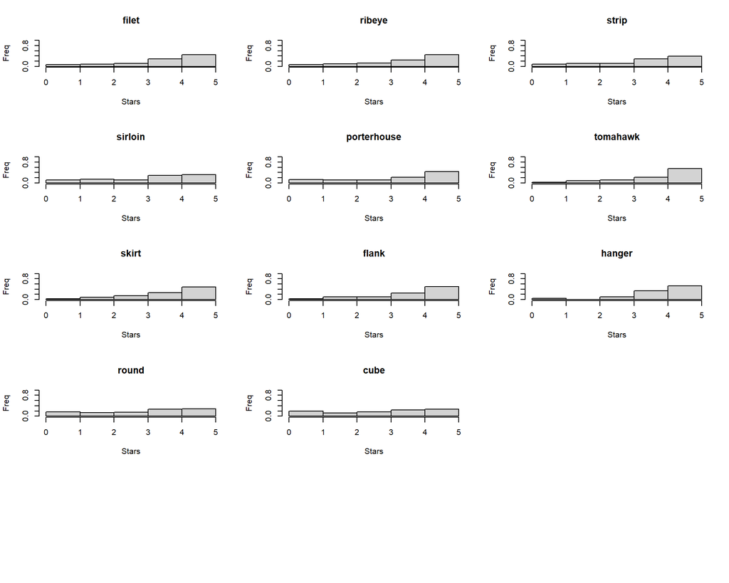

## Code Directions

The Rmd file is for knitting the summary file.

All the data are stored in the `data` directory.